# Step by step example for Bayesian inference: analytical solution

Fabienne Krauer

2022-09-05

## The question

Let’s assume we have a map of the world, and we want to figure out what proportion p is covered by water.

## The data

Do answer the question, we close our eyes and randomly point at the map and write down whether it is Water (0) or Land (1). We get the following data:

```r
data = c(0,0,1,0,1,1,0,1,1,1,0,0,1,0,0,0,1,0,1,0,1,0,0,1,0,0,1,1,0,0,1,0,1,0,0,1,0,1,0,0,0,0)
table(data)
```

```
## data
##  0  1
## 25 17
```

## The likelihood

The likelihood function that describes the process of multiple Bernoulli events (0 or 1) is a Binomial likelihood.

The parametrization requires to input the number of trials (=data points) and the number of successes (=n of data points with the value of interest (water)):

```r
loglik <- function(data, p) {

  trials = length(data)
  success = length(data[data==0])
  ll = dbinom(success, trials, p)

  return(ll)

}
```

Let’s visualize the log-likelihood profile for a series of probabilities p = proportion of the globe covered with water:

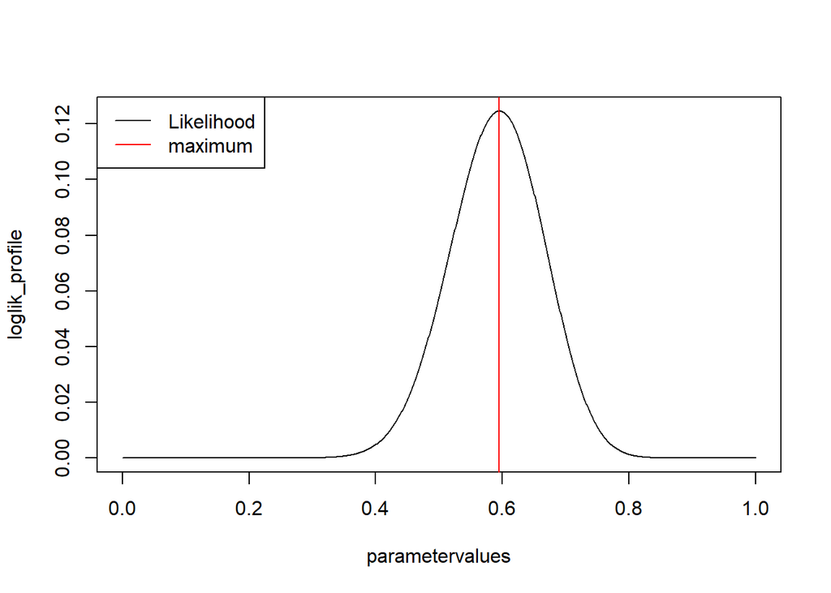

```r
# parameters to check
parametervalues <- seq(0,1,0.001)
# get the probability for all parametervalues
loglik_profile <- loglik(data, parametervalues)
# plot results
plot(parametervalues, loglik_profile, type = "l")
legend("topleft", legend = c("Likelihood", "maximum"), col = c("black", "red"), lwd = 1)
abline(v=parametervalues[which.max(loglik_profile)], col = "red")
```

## The prior

Let’s first assume we know nothing about how much landmass and watermass there is. We define an uniformative (flat/uniform) prior for the probability p:

# Set up the prior function

```r
prior_unif <- function(p){
    prior <- dunif(p, min=0, max=1)
    return(prior)
}
prior <- prior_unif(parametervalues)
```

## The posterior

Remember that posterior = (likelihood * prior) / marginal likelihood.

The marginal likelihood (=normalisation constant) is the weighted average of the prior times the log-likelihood function over all possible values of theta.

```r
marg_loglik <- sum(loglik_profile * prior) / length(parametervalues)
```

In the analytical solution, we evaluate the log-likelihood function at every potential value of the parameter (p), hence the posterior is:

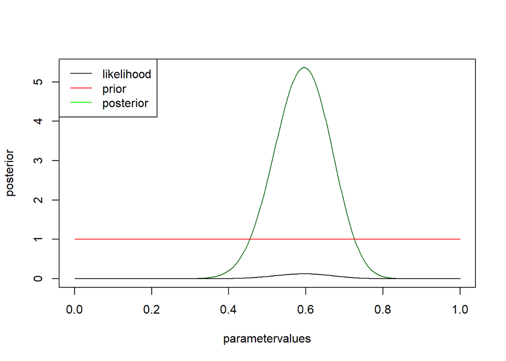

```r
posterior <- loglik_profile * prior / marg_loglik

plot(parametervalues, posterior, col = "darkgreen", type = "l")
lines(parametervalues, loglik_profile)
lines(parametervalues, prior, col = "red" )
legend("topleft", c("likelihood", "prior", "posterior"), col = c("black", "red", "green"), lwd = 1 )
```

Since our prior is flat, the posterior has the same shape as the log-likelihood profile. However, the area under the curve of the posterior is now 1 (i.e. it integrates to one), because it is now a proper probability distribution for one parameter.

## Rethinking the prior

But actually we know from some previous geographical measurements (“literature”) that the water mass is roughly 71%.

Let’s change the prior to a narrow Beta distribution with Beta(75,25) with a mean of 0.75:

```r
prior_beta <- function(p, shape1, shape2){
    prior <- dbeta(p, shape1 = shape1, shape2 = shape2)
    return(prior)
}
prior <- prior_beta(parametervalues, 75, 25)
```

Update the marginal loglikelihood and recalculate the prior:

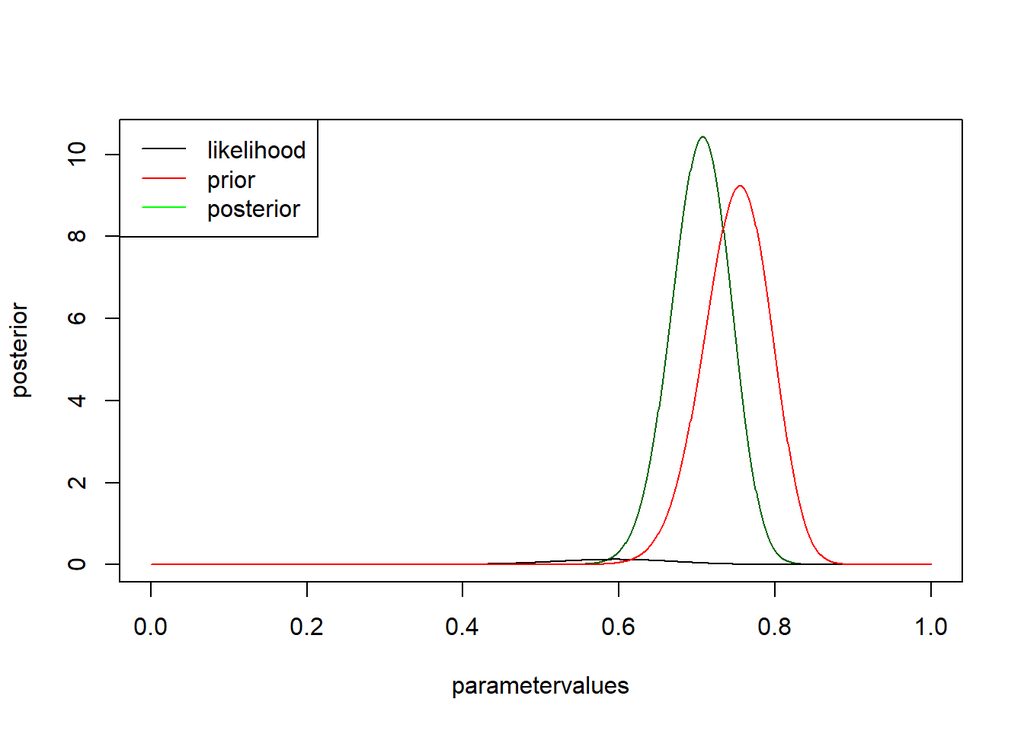

```r
marg_loglik <- sum(loglik_profile * prior) / length(parametervalues)
posterior <- loglik_profile * prior / marg_loglik

plot(parametervalues, posterior, col = "darkgreen", type = "l")
lines(parametervalues, loglik_profile)
lines(parametervalues, prior, col = "red" )
legend("topleft", c("likelihood", "prior", "posterior"), col = c("black", "red", "green"), lwd = 1 )
```

The prior has pulled the posterior away from the log-likelihood because it is a tight prior distribution.

We can repeat it with a wider Beta prior Beta(15,5), which has the same mean, but a larger variance:

```r
prior <- prior_beta(parametervalues, 15, 5)
```

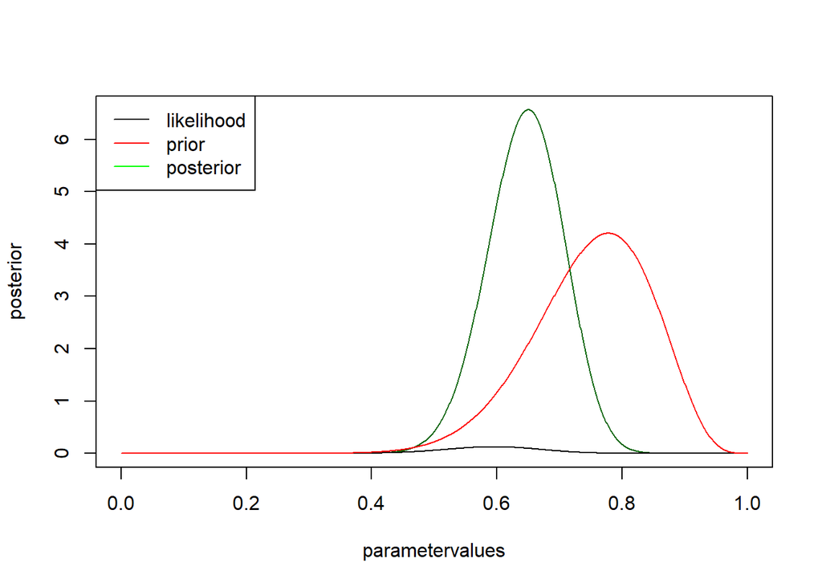

```r
marg_loglik <- sum(loglik_profile * prior) / length(parametervalues)
posterior <- loglik_profile * prior / marg_loglik

plot(parametervalues, posterior, col = "darkgreen", type = "l")
lines(parametervalues, loglik_profile)
lines(parametervalues, prior, col = "red" )
legend("topleft", c("likelihood", "prior", "posterior"), col = c("black", "red", "green"), lwd = 1 )
```

## Disclaimer

This example is based on Richard McElreath’s “globe tossing” example in “Statistical Rethinking” (3rd edition), see page 45. The code is adapted from [Florian Hartig](https://github.com/florianhartig/LearningBayes/blob/master/CommentedCode/01-Principles/InferenceMethods.md).